# Meta data random forest and shap

Emily Yeo

2024-09-29

# Read in Aim 1 meta

```r
m1_dir <- "/Users/emily/projects/research/Stanislawski/comps/mutli-omic-predictions/data/clinical/transformed/aim1"

# Create the full file path using paste
test <- read.csv(paste(m1_dir, "test_samples_standard_clinical.csv", sep = "/"))
train <- read.csv(paste(m1_dir, "train_samples_standard_clinical.csv", sep = "/"))
all_m <- read.csv(paste(m1_dir, "a1_meta_Transformed_standard_clinical.csv", sep = "/"))
```

# Working on models

There seem to be a million ways to do this. So here I am exploring it

## randomForest package

https://modeloriented.github.io/treeshap/

```r
rf <-randomForest(outcome_BMI_fnl_BL~.,data=train, ntree=500)
print(rf)
```

```
##
## Call:
##  randomForest(formula = outcome_BMI_fnl_BL ~ ., data = train,      ntree = 500)
##                Type of random forest: regression
##                      Number of trees: 500
## No. of variables tried at each split: 4
##
##           Mean of squared residuals: 0.8701378
##                     % Var explained: 12.3
```

```r
floor(sqrt(ncol(train) - 1))
```

```
## [1] 3
```

The number of variables selected at each split is denoted by mtry in randomforest function. Step III : Find the optimal mtry value Select mtry value with minimum out of bag(OOB) error.

```
## mtry = 3  OOB error = 0.8865201
## Searching left ...
## mtry = 2     OOB error = 0.8824734
## 0.004564618 0.01
## Searching right ...
## mtry = 4     OOB error = 0.8689491
## 0.01982017 0.01
## mtry = 6     OOB error = 0.895832
## -0.03093728 0.01
```

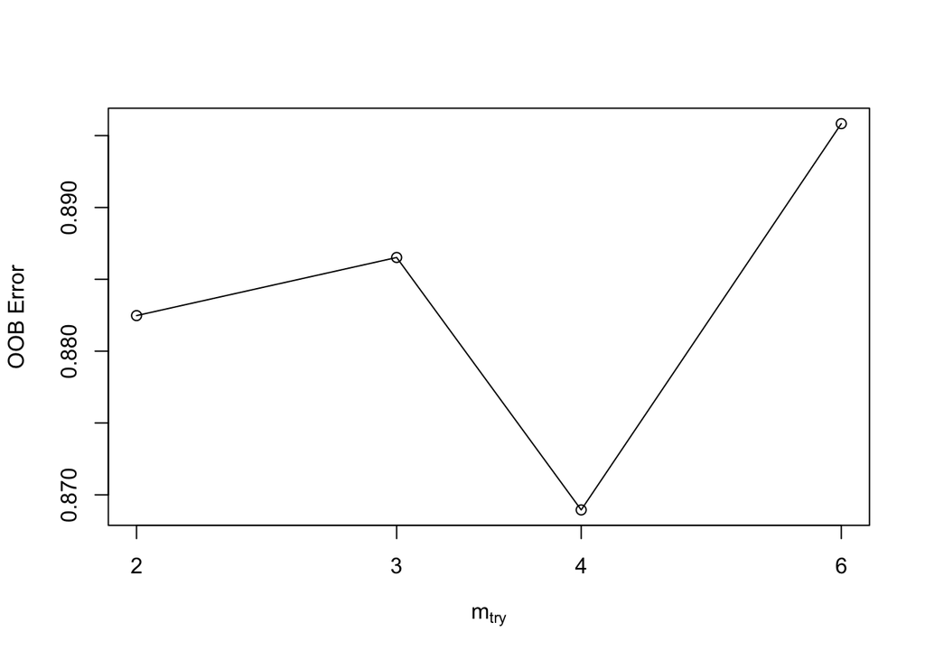

```r
mtry <- tuneRF(train[4:12],train$outcome_BMI_fnl_BL, ntreeTry=500,
               stepFactor=1.5,improve=0.01, trace=TRUE, plot=TRUE)
```

```r
best.m <- mtry[mtry[, 2] == min(mtry[, 2]), 1]
print(mtry)
```

```
##   mtry  OOBError
## 2    2 0.8824734
## 3    3 0.8865201
## 4    4 0.8689491
## 6    6 0.8958320
```

```r
print(best.m)
```

```
## [1] 4
```

Parameters in **tuneRF** function above

- The stepFactor specifies at each iteration, mtry is inflated (or deflated) by this value
- The improve specifies the (relative) improvement in OOB error must be by this much for the search to continue
- The trace specifies whether to print the progress of the search
- The plot specifies whether to plot the OOB error as function of mtry

```r
set.seed(71)
rf <-randomForest(outcome_BMI_fnl_BL~.,data=train[4:13], mtry=best.m,
                  importance=TRUE,ntree=500)
print(rf)
```

```
##
## Call:
##  randomForest(formula = outcome_BMI_fnl_BL ~ ., data = train[4:13],      mtry = best.m, importance = TRUE, ntree = 500)
##                Type of random forest: regression
##                      Number of trees: 500
## No. of variables tried at each split: 4
##
##           Mean of squared residuals: 0.9134998
##                     % Var explained: 7.93
```

```r
#Evaluate variable importance
importance(rf)
```

```
##                              %IncMSE IncNodePurity
## randomized_group          -0.3343993      1.444832
## sex                        0.7284039      1.290130
## age                        0.1361360     12.576091
## Triglyceride_lipid_BL      1.8802702     19.293681
## HDL_Total_Direct_lipid_BL -4.9777577      9.384730
## LDL_Calculated_BL         -2.0602275     10.272750
## Glucose_BL                 1.0527073     11.662672
## Insulin_endo_BL           15.4037978     23.415726
## HOMA_IR_BL                12.1058525     28.163190
```

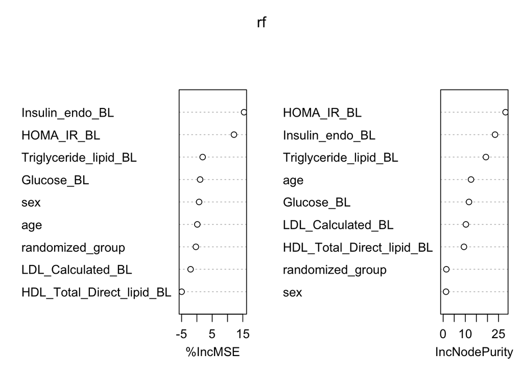

```r
varImpPlot(rf)
```

For each tree, the prediction accu- racy on the out-of-bag portion of the data is recorded. Then the same is done after permuting each predictor variable. The difference between the two accuracies are then averaged over all trees, and normalized by the standard error. For regression, the MSE is computed on the out-of-bag data for each tree, and then the same computed after permuting a variable. The differences are averaged and normalized by the standard error. If the standard error is equal to 0 for a variable, the division is not done.” varImp.randomForest is a simple wrapper around the importance function from that package. Similarly, for RandomForest objects, varImp is a wrapper around varimp in the party package.

### Prediction and Calculate Performance Metrics

```r
# Get predictions
pred1 <- predict(rf)

# Evaluate regression performance
rmse_value <- rmse(train$outcome_BMI_fnl_BL, pred1)
print(paste("RMSE:", rmse_value))
```

```
## [1] "RMSE: 0.955771817398478"
```

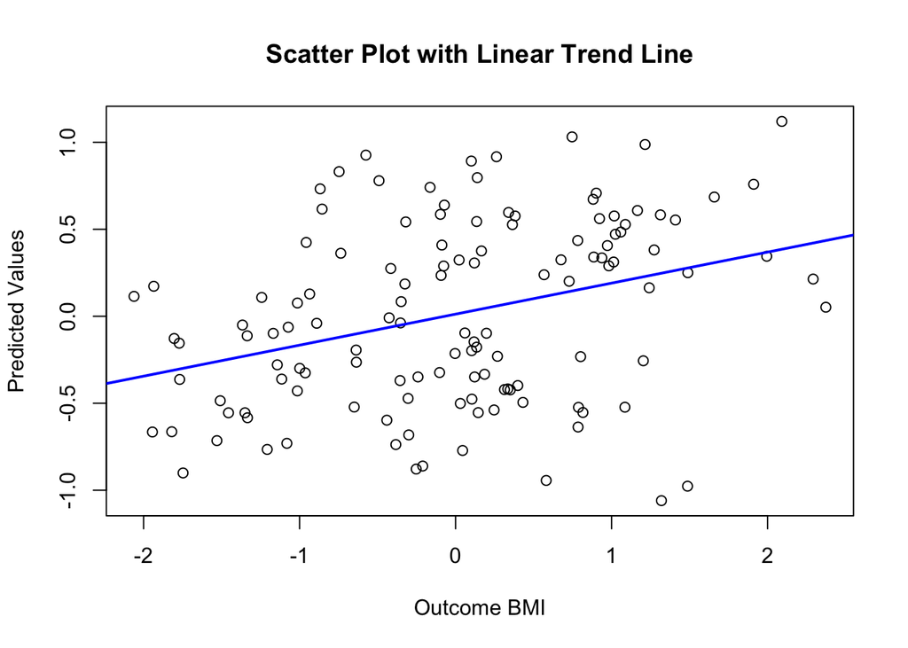

```
## integer(0)
```

```r
# Fit a linear model between actual and predicted
model <- lm(pred1 ~ train$outcome_BMI_fnl_BL)
plot(train$outcome_BMI_fnl_BL, pred1,
     xlab = "Outcome BMI",
     ylab = "Predicted Values",
     main = "Scatter Plot with Linear Trend Line") +
  abline(model, col = "blue", lwd = 2)
```

## RF with Caret

```r
fitControl <- trainControl(## 10-fold CV
                           method = "repeatedcv",
                           number = 10,
                           repeats = 10, ## k-fold repeated ten times
                           p = 0.80,
                           verboseIter = TRUE,
                           summaryFunction = defaultSummary,
                           selectionFunction = "best",
                           savePredictions = "final")

gbmFit1 <- train(outcome_BMI_fnl_BL ~ ., data = train[4:13],
                 method = "rf",
                 trControl = fitControl,
                 verbose = TRUE)
gbmFit1
```

```
## Random Forest
##
## 127 samples
##   9 predictor
##
## No pre-processing
## Resampling: Cross-Validated (10 fold, repeated 10 times)
## Summary of sample sizes: 115, 114, 114, 114, 114, 114, ...
## Resampling results across tuning parameters:
##
##   mtry  RMSE       Rsquared   MAE
##   2     0.9194373  0.2035015  0.7728508
##   5     0.9282902  0.2035370  0.7808855
##   9     0.9305309  0.2083761  0.7786948
##
## RMSE was used to select the optimal model using the smallest value.
## The final value used for the model was mtry = 2.
```

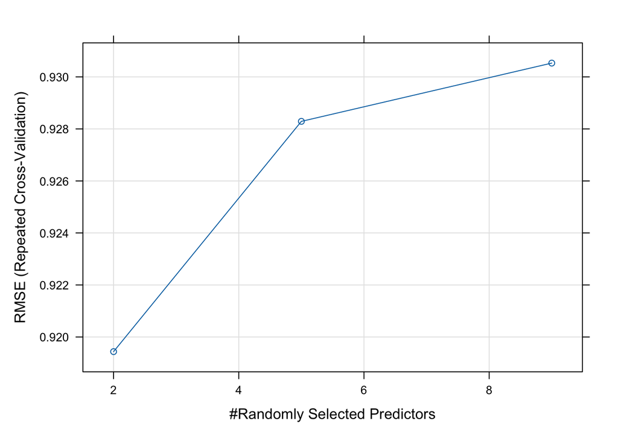

```r
plot(gbmFit1)
```

### What is the best mtry parameter

```r
gbmFit1$bestTune
```

```
##   mtry
## 1    2
```

```r
head(gbmFit1$results)
```

```
##   mtry      RMSE  Rsquared       MAE    RMSESD RsquaredSD     MAESD
## 1    2 0.9194373 0.2035015 0.7728508 0.1243469  0.1790760 0.1031845
## 2    5 0.9282902 0.2035370 0.7808855 0.1353724  0.1785775 0.1067056
## 3    9 0.9305309 0.2083761 0.7786948 0.1447408  0.1807285 0.1123734
```

### Variable Importance

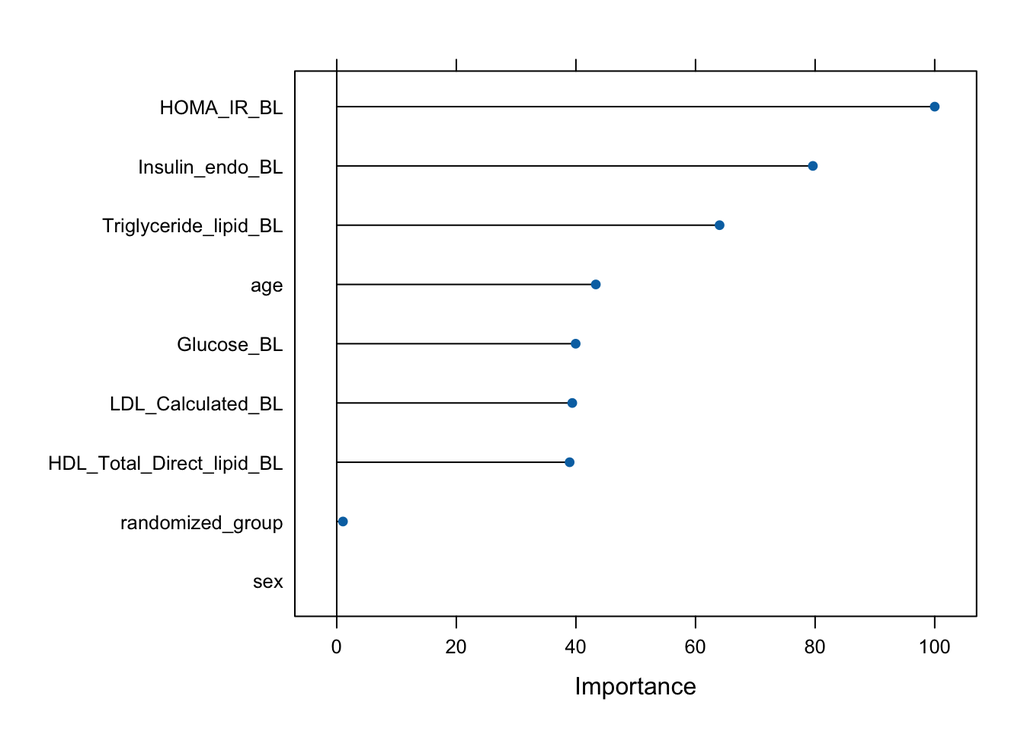

```r
gbmImp <- varImp(gbmFit1, scale = TRUE)
plot(gbmImp)
```

### Feature selections

Using simple backwards selection, a.k.a. recursive feature elimination (RFE), algorithm

```r
# define the control using a random forest selection function
control <- rfeControl(functions=rfFuncs, method="cv", number=10)
# run the RFE algorithm
results <- rfe(train[,4:12],
               train[,13],
               sizes=c(4:13),
               rfeControl=control)

print(results)
```

```
##
## Recursive feature selection
##
## Outer resampling method: Cross-Validated (10 fold)
##
## Resampling performance over subset size:
##
##  Variables   RMSE Rsquared    MAE  RMSESD RsquaredSD   MAESD Selected
##          4 0.9430   0.1553 0.7621 0.09636     0.1461 0.08827
##          5 0.9348   0.1550 0.7686 0.10237     0.1258 0.10369
##          6 0.9290   0.1863 0.7641 0.10694     0.1434 0.09322        *
##          7 0.9304   0.1807 0.7687 0.10844     0.1577 0.09682
##          8 0.9344   0.1660 0.7777 0.09094     0.1464 0.08174
##          9 0.9365   0.1636 0.7805 0.08801     0.1342 0.07497
##
## The top 5 variables (out of 6):
##    Insulin_endo_BL, HOMA_IR_BL, Triglyceride_lipid_BL, Glucose_BL, sex
```

```r
chosen_features <- predictors(results) # list the chosen features
print(paste0("The chosen features are: ", chosen_features))
```

```
## [1] "The chosen features are: Insulin_endo_BL"
## [2] "The chosen features are: HOMA_IR_BL"
## [3] "The chosen features are: Triglyceride_lipid_BL"
## [4] "The chosen features are: Glucose_BL"
## [5] "The chosen features are: sex"
## [6] "The chosen features are: age"
```

The plot may highlight the optimal number of features that gives the best model performance.

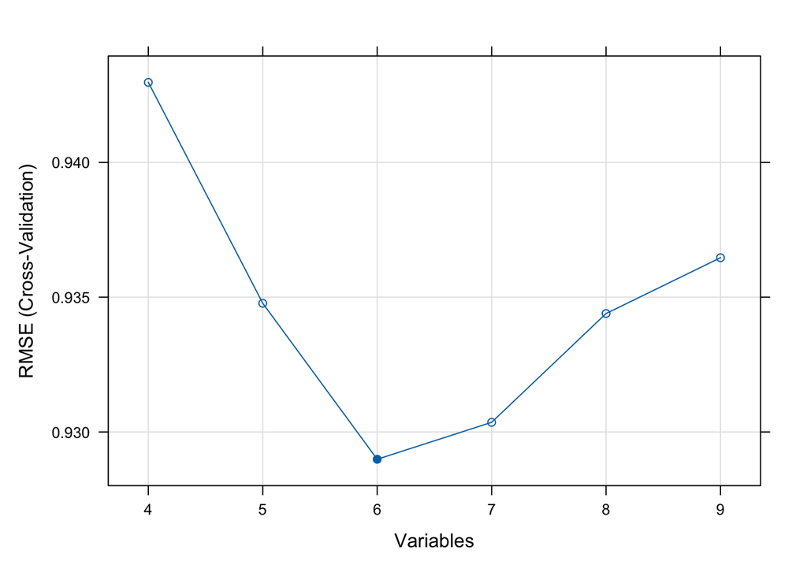

```r
plot(results, type=c("g", "o")) # plot the results
```

## Using mtry grid search algorithms

From this tutorial: https://machinelearningmastery.com/tune-machine-learning-algorithms-in-r/

```r
dataset <- train
x <- dataset[,4:12]
y <- dataset[,13]

# Create model with default paramters
control <- trainControl(method="repeatedcv", number=10, repeats=3)
seed <- 7
metric <- "RMSE"
set.seed(seed)
mtry <- sqrt(ncol(x))
tunegrid <- expand.grid(.mtry=mtry)
rf_default <- train(outcome_BMI_fnl_BL ~., data=dataset[4:13],
                    method="rf",
                    metric=metric,
                    tuneGrid=tunegrid,
                    trControl=control)
print(rf_default)
```

```
## Random Forest
##
## 127 samples
##   9 predictor
##
## No pre-processing
## Resampling: Cross-Validated (10 fold, repeated 3 times)
## Summary of sample sizes: 115, 114, 114, 114, 113, 115, ...
## Resampling results:
##
##   RMSE       Rsquared   MAE
##   0.9202999  0.2012073  0.7768784
##
## Tuning parameter 'mtry' was held constant at a value of 3
```

### Rtrying wuth random search mtry

```r
control <- trainControl(method="repeatedcv", number=10, repeats=3, search="random")
set.seed(seed)
mtry <- sqrt(ncol(x))
rf_random <- train(outcome_BMI_fnl_BL~., data=dataset[4:13],
                   method="rf",
                   metric=metric,
                   tuneLength=15, trControl=control)
print(rf_random)
```

```
## Random Forest
##
## 127 samples
##   9 predictor
##
## No pre-processing
## Resampling: Cross-Validated (10 fold, repeated 3 times)
## Summary of sample sizes: 115, 114, 114, 114, 113, 115, ...
## Resampling results across tuning parameters:
##
##   mtry  RMSE       Rsquared   MAE
##   2     0.9169456  0.2019774  0.7728573
##   3     0.9213020  0.2039601  0.7790831
##   4     0.9212442  0.2023399  0.7771397
##   6     0.9263438  0.2042145  0.7774785
##   7     0.9243136  0.2088891  0.7770437
##   8     0.9279895  0.2073587  0.7781359
##
## RMSE was used to select the optimal model using the smallest value.
## The final value used for the model was mtry = 2.
```

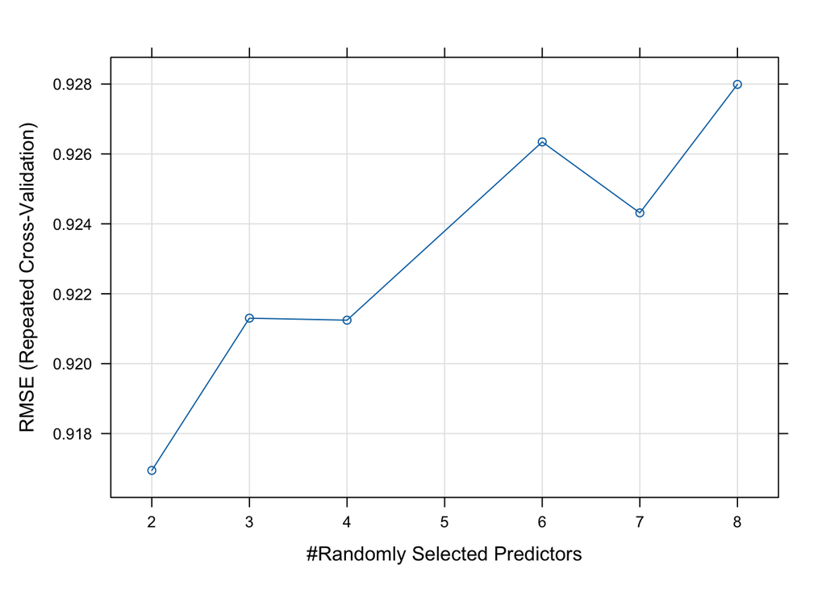

```r
plot(rf_random)
```

### tuning using grid search

Using this method. It appears 2 is the best mtry parameter

```r
control <- trainControl(method="repeatedcv", number=10, repeats=3, search="grid")
set.seed(seed)
tunegrid <- expand.grid(.mtry=c(1:15))
rf_gridsearch <- train(outcome_BMI_fnl_BL~., data=dataset[4:13],
                       method="rf", metric=metric,
                       tuneGrid=tunegrid, trControl=control)
print(rf_gridsearch)
```

```
## Random Forest
##
## 127 samples
##   9 predictor
##
## No pre-processing
## Resampling: Cross-Validated (10 fold, repeated 3 times)
## Summary of sample sizes: 115, 114, 114, 114, 113, 115, ...
## Resampling results across tuning parameters:
##
##   mtry  RMSE       Rsquared   MAE
##    1    0.9173411  0.1981889  0.7653767
##    2    0.9142991  0.2035752  0.7714826
##    3    0.9198644  0.2021996  0.7767088
##    4    0.9238026  0.2018095  0.7791396
##    5    0.9210968  0.2104108  0.7749707
##    6    0.9288260  0.2029134  0.7809383
##    7    0.9299928  0.2017745  0.7778544
##    8    0.9290158  0.2042177  0.7767014
##    9    0.9297496  0.2017100  0.7771435
##   10    0.9253028  0.2112313  0.7731953
##   11    0.9269820  0.2098529  0.7758474
##   12    0.9280651  0.2044940  0.7755802
##   13    0.9259428  0.2085329  0.7726620
##   14    0.9289832  0.2074217  0.7760324
##   15    0.9309050  0.2033713  0.7808986
##
## RMSE was used to select the optimal model using the smallest value.
## The final value used for the model was mtry = 2.
```

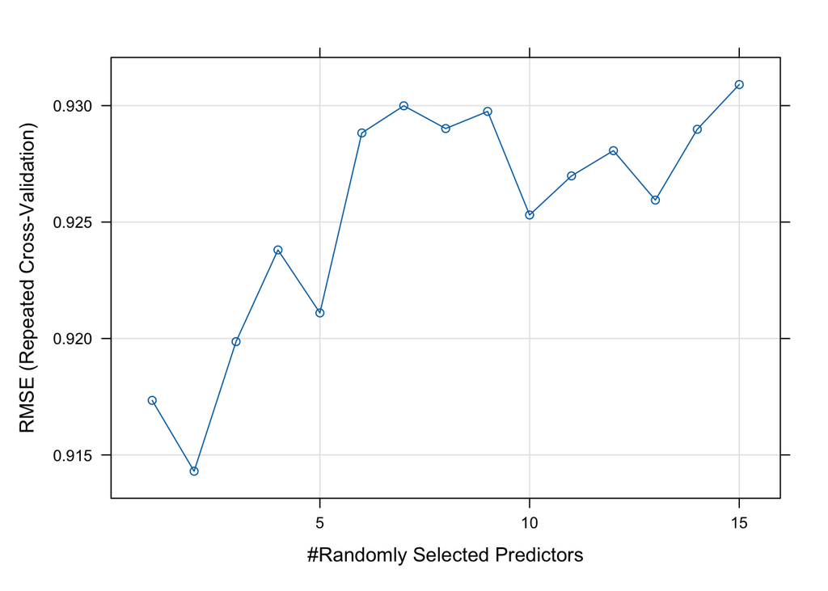

```r
plot(rf_gridsearch)
```

## Tune using tuneRF algorithms

Some algorithms provide tools for tuning the parameters of the algorithm.

For example, the random forest algorithm implementation in the randomForest package provides the tuneRF() function that searches for optimal mtry values given your data.

```r
# Algorithm Tune (tuneRF)
set.seed(seed)
bestmtry <- tuneRF(x, y, stepFactor=1.5, improve=1e-5, ntree=500)
```

```
## mtry = 3  OOB error = 0.8907047
## Searching left ...
## mtry = 2     OOB error = 0.8581652
## 0.03653221 1e-05
## Searching right ...
## mtry = 4     OOB error = 0.890603
## -0.03779896 1e-05
```

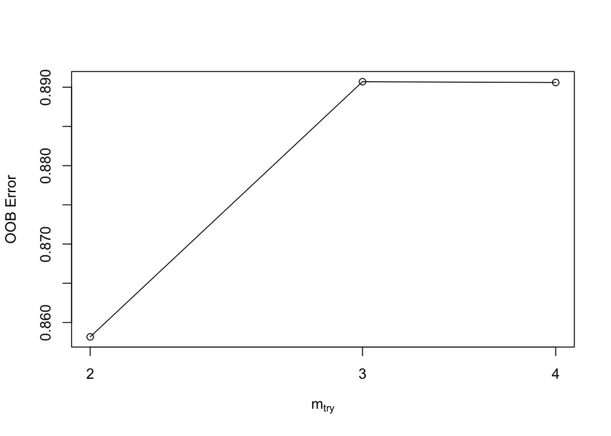

```r
print(bestmtry)
```

```
##   mtry  OOBError
## 2    2 0.8581652
## 3    3 0.8907047
## 4    4 0.8906030
```

## Tune Manually

We want to keep using caret because it provides a direct point of comparison to our previous models (apples to apples, even the same data splits) and because of the repeated cross validation test harness that we like as it reduces the severity of overfitting.

One approach is to create many caret models for our algorithm and pass in a different parameters directly to the algorithm manually. Here I am looking at different ntree values while keeping mtry constant.

```r
# Manual Search
control <- trainControl(method="repeatedcv", number=10, repeats=3, search="grid")
tunegrid <- expand.grid(.mtry=c(sqrt(ncol(x))))
modellist <- list()
for (ntree in c(1000, 1500, 2000, 2500)) {
    set.seed(seed)
    fit <- train(outcome_BMI_fnl_BL~., data=dataset[4:13],
                 method="rf",
                 metric=metric,
                 tuneGrid=tunegrid,
                 trControl=control,
                 ntree=ntree)
    key <- toString(ntree)
    modellist[[key]] <- fit
}
# compare results
results <- resamples(modellist)
```

##### Compare the models

```r
summary(results)
```

```
##
## Call:
## summary.resamples(object = results)
##
## Models: 1000, 1500, 2000, 2500
## Number of resamples: 30
##
## MAE
##           Min.   1st Qu.    Median      Mean   3rd Qu.     Max. NA's
## 1000 0.4842022 0.7078552 0.7610018 0.7759233 0.8069719 1.073381    0
## 1500 0.4890223 0.7088717 0.7630390 0.7764191 0.8062700 1.071450    0
## 2000 0.4866272 0.7109262 0.7611534 0.7763170 0.8071892 1.073354    0
## 2500 0.4847077 0.7078874 0.7639352 0.7766257 0.8057720 1.074828    0
##
## RMSE
##           Min.   1st Qu.    Median      Mean   3rd Qu.     Max. NA's
## 1000 0.5676674 0.8302450 0.9005231 0.9202295 0.9736244 1.287357    0
## 1500 0.5730361 0.8275796 0.8991389 0.9199974 0.9604031 1.285256    0
## 2000 0.5689149 0.8285020 0.8973998 0.9192492 0.9619032 1.287103    0
## 2500 0.5663835 0.8286109 0.8971216 0.9196298 0.9633779 1.289134    0
##
## Rsquared
##              Min.    1st Qu.    Median      Mean   3rd Qu.      Max. NA's
## 1000 3.396486e-05 0.06746894 0.1554211 0.2009672 0.2772704 0.6860980    0
## 1500 1.749599e-04 0.06862289 0.1642917 0.2020068 0.2817110 0.6861971    0
## 2000 1.155527e-04 0.06827537 0.1618791 0.2032691 0.2852623 0.6939297    0
## 2500 1.418653e-04 0.07076660 0.1603097 0.2028648 0.2852151 0.6958809    0
```

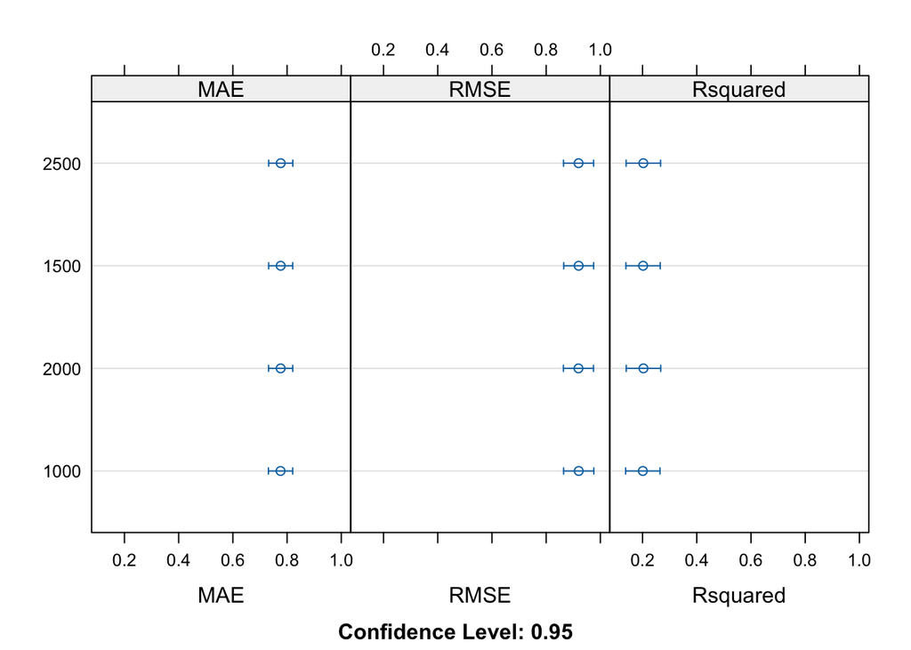

```r
dotplot(results)
```

## Extend Caret Algorithms

Not feeling like this is something to dabble with right

# Baruta and SHAP

This is still something I’m figuring out. But doesn’t look too bad.

## Boruta

You could consider increasing the maxRuns parameter if tentative features are left. However, note that you can also provide values of mtry and ntree parameters, which will be passed to randomForest() function.

```r
library(Boruta)
set.seed(111)
boruta.bank_train <- Boruta(outcome_BMI_fnl_BL~.,
                            data = train[4:13],
                            doTrace = 2)
```

[output not shown]

[output not shown]

[output not shown]

[output not shown]

[output not shown]

[output not shown]

[output not shown]

[output not shown]

[output not shown]

[output not shown]

```
## After 10 iterations, +0.22 secs:
```

```
##  confirmed 2 attributes: HOMA_IR_BL, Insulin_endo_BL;
```

```
##  rejected 7 attributes: age, Glucose_BL, HDL_Total_Direct_lipid_BL, LDL_Calculated_BL, randomized_group and 2 more;
```

```
##  no more attributes left.
```

```r
print(boruta.bank_train)
```

```
## Boruta performed 10 iterations in 0.2182131 secs.
##  2 attributes confirmed important: HOMA_IR_BL, Insulin_endo_BL;
##  7 attributes confirmed unimportant: age, Glucose_BL,
## HDL_Total_Direct_lipid_BL, LDL_Calculated_BL, randomized_group and 2
## more;
```

The boruta package also contains a TentativeRoughFix() function, which can be used to fill missing decisions by simple comparison of the median feature Z-score with the median Z-score of the most important shadow feature:

```r
#take a call on tentative features
boruta.bank <- TentativeRoughFix(boruta.bank_train)
print(boruta.bank)
```

```
## Boruta performed 10 iterations in 0.2182131 secs.
##  2 attributes confirmed important: HOMA_IR_BL, Insulin_endo_BL;
##  7 attributes confirmed unimportant: age, Glucose_BL,
## HDL_Total_Direct_lipid_BL, LDL_Calculated_BL, randomized_group and 2
## more;
```

Plot features:

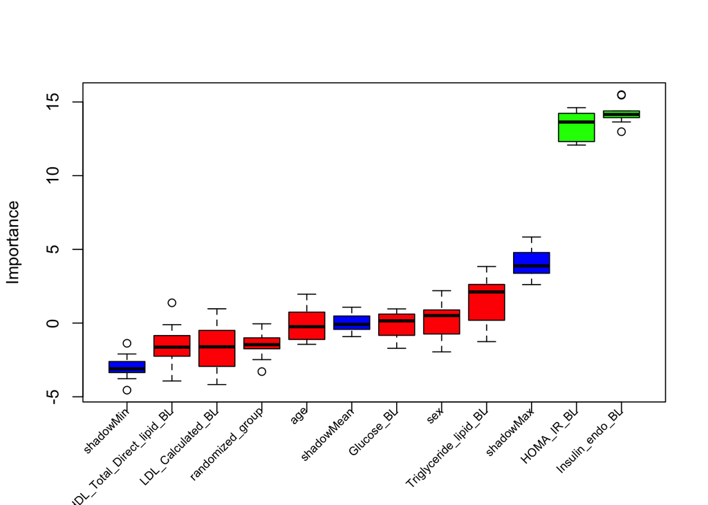

```r
plot(boruta.bank, xlab = "", xaxt = "n")

lz <- lapply(1:ncol(boruta.bank$ImpHistory), function(i) {
  boruta.bank$ImpHistory[is.finite(boruta.bank$ImpHistory[, i]), i]
})

names(lz) <- colnames(boruta.bank$ImpHistory)
Labels <- sort(sapply(lz, median))

# Create the axis without labels
axis(side = 1, at = 1:ncol(boruta.bank$ImpHistory), labels = FALSE)

# Add labels at a 45-degree angle
text(x = 1:ncol(boruta.bank$ImpHistory),
     y = par("usr")[3] - 0.5,  # Adjust the y position as needed
     labels = names(Labels),
     srt = 45,
     adj = 1,
     xpd = TRUE,
     cex = 0.7)
```

The y axis label Importance represents the Z score of every feature in the shuffled dataset.

The blue boxplots correspond to minimal, average and maximum Z score of a shadow feature, while the red and green boxplots represent Z scores of rejected and confirmed features, respectively. As you can see the red boxplots have lower Z score than that of maximum Z score of shadow feature which is precisely the reason they were put in unimportant category.

Summary of confirmed features:

```r
bank_df <- attStats(boruta.bank)
print(bank_df)
```

```
##                               meanImp  medianImp    minImp      maxImp normHits
## randomized_group          -1.48591427 -1.4626546 -3.290514 -0.04835449        0
## sex                        0.15924534  0.5097835 -1.951994  2.19917553        0
## age                       -0.09143355 -0.2447529 -1.440735  1.95845877        0
## Triglyceride_lipid_BL      1.64668693  2.1134479 -1.257200  3.83918339        0
## HDL_Total_Direct_lipid_BL -1.48825310 -1.6360630 -3.927550  1.37610428        0
## LDL_Calculated_BL         -1.67098790 -1.6101904 -4.169847  0.96952068        0
## Glucose_BL                -0.14043811  0.1529021 -1.712638  0.96045429        0
## Insulin_endo_BL           14.25457378 14.1552897 12.981791 15.49617590        1
## HOMA_IR_BL                13.40828257 13.6376814 12.077415 14.61293972        1
##                            decision
## randomized_group           Rejected
## sex                        Rejected
## age                        Rejected
## Triglyceride_lipid_BL      Rejected
## HDL_Total_Direct_lipid_BL  Rejected
## LDL_Calculated_BL          Rejected
## Glucose_BL                 Rejected
## Insulin_endo_BL           Confirmed
## HOMA_IR_BL                Confirmed
```

```r
# use a RF model from above

# Calculate SHAP values using the 'iml' package
# predictor <- Predictor$new(rf_model,
#                            data = data[, -which(names(data) == "target")],
#                            type = "prob")
#
# shapley_values <- Shapley$new(predictor, x.interest = data[1, -which(names(data) == "target")]) # Example for one instance
#
# # Plot SHAP values
# plot(shapley_values)
```